# Análisis Factorial en R

Carlos A. Torres Cubilla

Noviembre de 2019

El modelo de Análisis Factorial es un modelo de regresión múltiple que relaciona variables latentes con variables observadas.

Para ejemplificar esta técnica se utilizará la base de datos **“TMMS”** sobre Inteligencia Emocional.

```r
TMMS = read.table('TMMS Tecnicas factoriales.txt')
```

Esta base de datos consta de 136 observaciones y 24 variables, las cuales se agrupan en tres grandes dimensiones que contienen 8 items cada una. Estas dimensiones se detallan a continuación:

- **Atención emocional:** capacidad de sentir y expresar los sentimientos de forma adecuada. Está conformada por los ítems del IE1 al IE8.
- **Claridad emocional:** capacidad de comprender los propios estados emocionales. Está conformada por los ítems del IE9 al IE16.
- **Reparación emocional:** capacidad de regular los estados emocionales correctamente. Está conformada por los ítems del IE17 al IE24.

# 1 Correlación entre variables

## 1.1 Matriz de correlación

Para que el análisis de correlación tenga sentido es necesario que exista correlaciones entre variables. Las variables con correlaciones altas se agruparán en una misma dimensión, mientras que las variables con correlaciones bajas se encontraran en dimensiones distintas.

```r
cor_TMMS = cor(TMMS)
round(cor_TMMS[1:8, 1:8], 4)
```

```
##        IE1    IE2    IE3    IE4    IE5    IE6    IE7    IE8
## IE1 1.0000 0.6983 0.5017 0.5707 0.4102 0.4244 0.5719 0.6547
## IE2 0.6983 1.0000 0.6125 0.5961 0.4635 0.5580 0.6091 0.7332
## IE3 0.5017 0.6125 1.0000 0.6494 0.3069 0.3693 0.5796 0.5939
## IE4 0.5707 0.5961 0.6494 1.0000 0.2657 0.3962 0.5896 0.6250
## IE5 0.4102 0.4635 0.3069 0.2657 1.0000 0.4719 0.4800 0.4275
## IE6 0.4244 0.5580 0.3693 0.3962 0.4719 1.0000 0.6966 0.6441
## IE7 0.5719 0.6091 0.5796 0.5896 0.4800 0.6966 1.0000 0.7267
## IE8 0.6547 0.7332 0.5939 0.6250 0.4275 0.6441 0.7267 1.0000
```

En ocasiones la cantidad de variables que se consideran son muchas, lo que dificulta la interpretación de la matriz de correlaciones. Por esta razón solo se imprimió en pantalla las correlaciones entre las ocho primeras variables.

## 1.2 Gráfico de correlaciones

Para solucionar el problema de interpretación de una matriz de correlación muy grande es común utilizar un gráfico de correlaciones. Para realizar este gráfico es necesario cargar la librería [`"corrplot"`](https://cran.r-project.org/web/packages/corrplot/vignettes/corrplot-intro.html). Esta dibuja un gráfico que muestra la correlación mediante colores y figuras geométricas, entre otras modalidades.

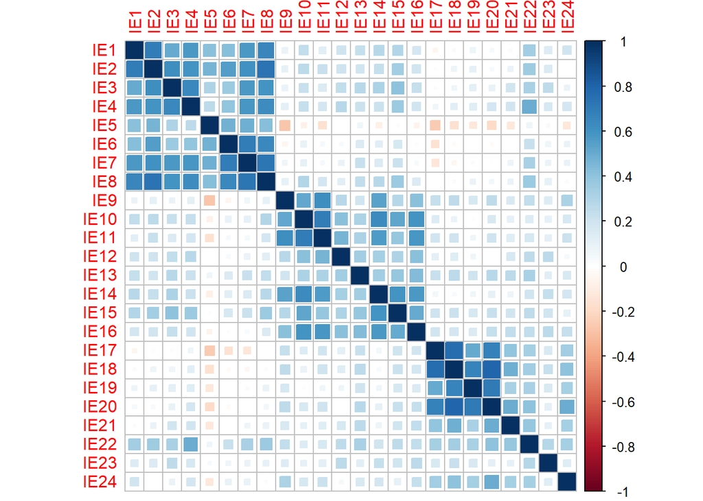

```r
library("corrplot")
corrplot(cor_TMMS, method = "square")
```

Al observar el gráfico de correlaciones se aprecia que la dimensión de atención se encuentra bien definida, la dimensión de claridad no se aprecia tan claro y en la dimensión reparación solo algunos ítems están correlacionados.

## 1.3 Determinante de la matriz de correlación

Si existe correlación entre variables el determinante de la matriz será próximo a cero. Si el determinante no es próximo a cero el Análisis Factorial no funcionará

```r
det(cor_TMMS)
```

```
## [1] 5.198459e-07
```

En este ejemplo, el determinante de la matriz de correlaciones tiende a cero, por lo que es adecuado aplicar un Análisis Factorial.

# 2 KMO y esfericidad de Barlett

Para la prueba de esfericidad y el estadístico KMO es necesario cargar la librería [`"psych"`](https://www.rdocumentation.org/packages/psych/versions/1.8.12), la cual es una librería orientada a la psicometría y psicología.

```r
library("psych")
```

## 2.1 Estadístico KMO

La medida de adecuación muestral KMO (Kaiser-Meyer-Olkin) contrasta si las correlaciones parciales entre las variables son suficientemente pequeñas. Permite comparar la magnitud de los coeficientes de correlación observados con la magnitud de los coeficientes de correlación parcial. Los expertos mencionan que la interpretación del estadístico KMO es la siguiente:

$$\begin{matrix}
KMO \ge 0.75 \Rightarrow Bien \\
KMO \ge 0.5 \Rightarrow Aceptable \\
KMO < 0.5 \Rightarrow Inaceptable
\end{matrix}$$

```r
KMO(cor_TMMS)$MSA
```

```
## [1] 0.8472908
```

El estadístico KMO es alto, por lo que es adecuado realizar un Análisis Factorial.

## 2.2 Prueba de esfericidad de Barlett

Las hipótesis a contrastar en la prueba de esfericidad de Barlett son:
$$\begin{matrix}
H_0: Matriz \quad de \quad correlaciones = Matriz \quad identidad \\
H_1: Matriz \quad de \quad correlaciones \neq Matriz \quad identidad
\end{matrix}$$

Una matriz identidad es una matriz cuadrada donde todos sus elementos son 0, menos los elementos de la diagonal principal que son 1. Si la matriz de correlaciones es una matriz identidad entonces eso implica que no existe correlación entre las variables en estudio, por lo que no es adecuado aplicar un Análisis Factorial. Por esta razón nos interesa rechazar la hipótesis nula.

```r
cortest.bartlett(cor_TMMS, n = 136)
```

```
## $chisq
## [1] 1825.598
##
## $p.value
## [1] 3.298084e-226
##
## $df
## [1] 276
```

Como p-valor < 0.05, se rechaza la hipótesis nula. La matriz de correlaciones no es una matriz identidad. Es adecuado realizar un Análisis Factorial.

# 3 Número de dimensiones consideradas

Para conocer el número de factores que se deben retener existen cuatro métodos distintos. Para realizar tres de ellos es necesario conocer los autovalores iniciales. La función `eigen` devuelve los autovalores y autovectores dada una matriz de correlación.

```r
autovalores = eigen(cor_TMMS)$values
```

## 3.1 Autovalores mayores que 1

El número de factores estará determinado por el número de valores propios mayores que uno.

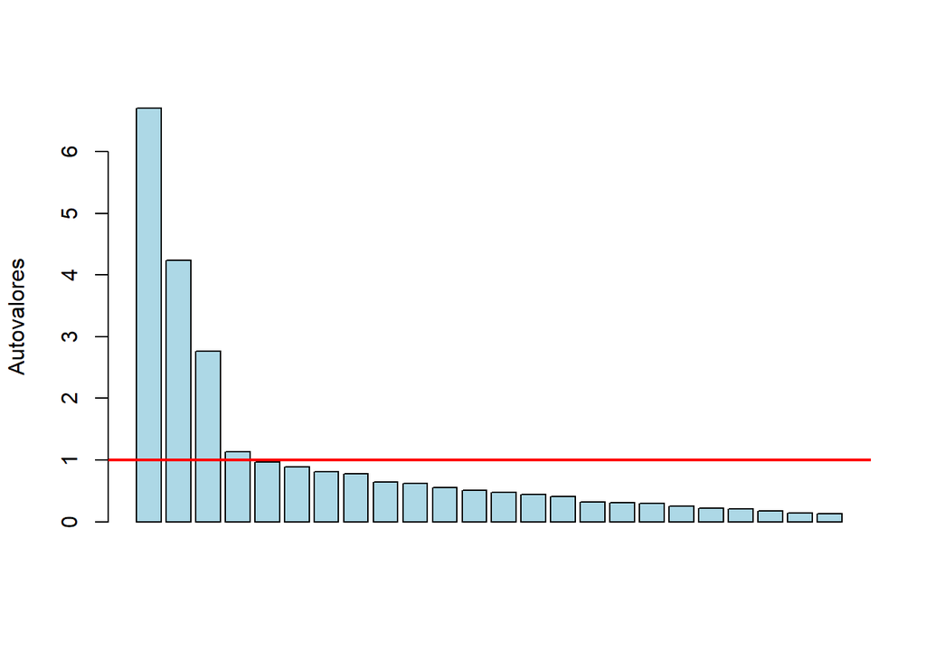

```r
barplot(autovalores,
        col = "lightblue",
        ylab = "Autovalores")
abline(h = 1, col = "red", lwd = 2)
```

Con este método se retienen 4 factores.

## 3.2 Regla del 75% de varianza

El número de factores está determinado por la absorción de inercia. Se tomarán tantos valores propios como sean necesarios para conseguir un 75% de inercia absorbida.

```r
total = sum(autovalores) # Suma de autovalores
var_exp = round(autovalores/total*100, 3) # Varianza explicada (%)
cumsum(var_exp) # Varianzas acumuladas
```

```
##  [1] 27.939 45.592 57.099 61.833 65.878 69.561 72.950 76.200 78.893 81.465
## [11] 83.769 85.888 87.870 89.717 91.443 92.777 94.047 95.276 96.344 97.249
## [21] 98.140 98.883 99.472 99.999
```

Con este método se retienen 8 factores.

## 3.3 Gráfico del codo o scree plot

El procedimiento del scree plot de Cattell consiste en representar gráficamente los valores propios en orden descendente y dibujar una recta a través de las componentes con los valores propios más bajos. Se retienen las componentes que se corresponden con los autovalores que quedan por encima de la línea.

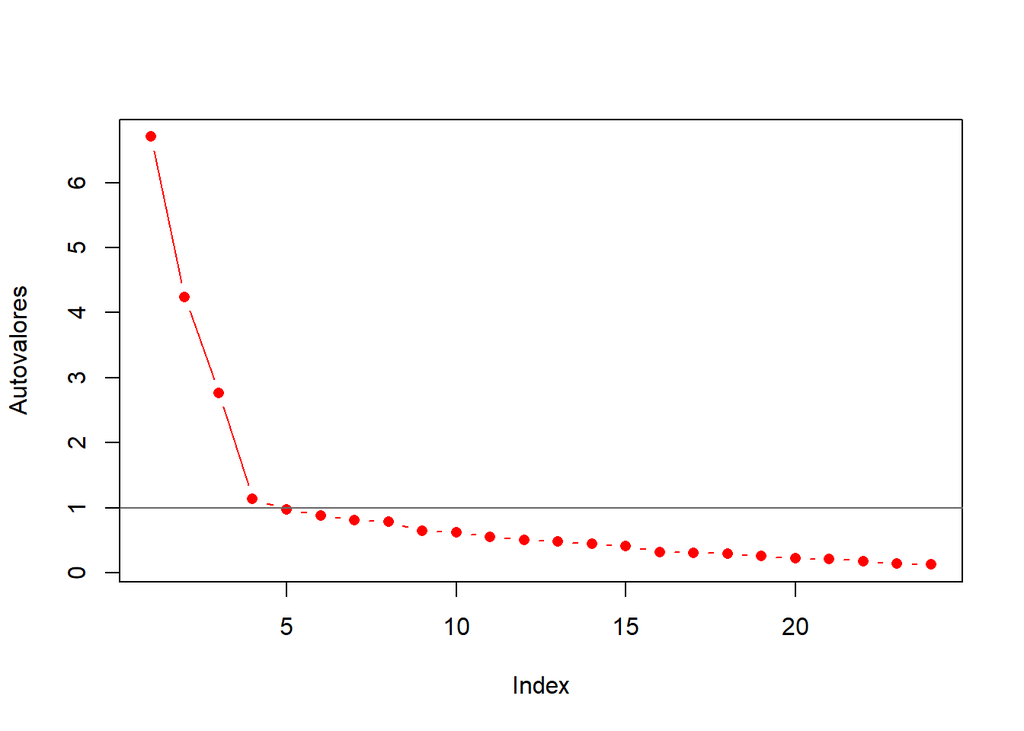

```r
plot(autovalores,
     pch = 16,
     col = "red",
     type = "b",
     ylab = "Autovalores")
abline(h = 1, col = "dimgray")
```

Con este método se retienen 4 factores.

## 3.4 Especificación del usuario

Es posible especificar personalmente el número de factores. Como se conoce que el test de IE esta recogido en tres variables latentes, se tomaran estas como el número de factores a retener.

# 4 Análisis Factorial

Para realizar el análisis factorial se utiliza la función `fa` de la librería [`"psych"`](https://www.rdocumentation.org/packages/psych/versions/1.8.12). Para esta función, el principal argumento es la matriz de datos (**TMMS**). También se especifica el número de factores, el tipo de rotación y el método de obtención de las puntuaciones factoriales.

## 4.1 Análisis Factorial sin rotar

```r
AF = fa(TMMS, nfactors = 3, rotate = "none", scores = "Bartlett")
AF$Structure
```

```
##
## Loadings:
##      MR1    MR2    MR3
## IE1   0.604 -0.427
## IE2   0.665 -0.480  0.118
## IE3   0.632 -0.344
## IE4   0.664 -0.310  0.169
## IE5   0.182 -0.591  0.190
## IE6   0.430 -0.516  0.185
## IE7   0.563 -0.575  0.223
## IE8   0.680 -0.518  0.135
## IE9   0.445  0.349 -0.343
## IE10  0.582  0.156 -0.556
## IE11  0.542  0.280 -0.514
## IE12  0.432        -0.290
## IE13  0.500  0.128
## IE14  0.584  0.109 -0.527
## IE15  0.615        -0.234
## IE16  0.568  0.267 -0.413
## IE17  0.326  0.631  0.322
## IE18  0.420  0.637  0.468
## IE19  0.357  0.448  0.430
## IE20  0.450  0.630  0.458
## IE21  0.362  0.353  0.248
## IE22  0.579         0.260
## IE23  0.309
## IE24  0.355  0.339  0.176
##
##                  MR1   MR2   MR3
## SS loadings    6.257 3.837 2.357
## Proportion Var 0.261 0.160 0.098
## Cumulative Var 0.261 0.421 0.519
```

Para verificar que se cumple la estructura de las dimensiones definidas a priori se analiza la matriz de saturaciones (`AF$loadings`) en valor absoluto. Aquellas variables que presentan altas saturaciones son las que tiene mayor importancia en la interpretación del eje. Las saturaciones se pueden representar sobre un gráfico de barras que permita la interpretación factorial de las mismas. Para esto se define el siguiente vector de colores:

```r
colores = c(rep("orange", 8),
            rep("yellow", 8),
            rep("green", 8))
```

Con los colores definidos anteriormente se pintan los distintos gráficos de barra de cada dimensión utilizando colores distintos para los ítems que componen cada dimensión.

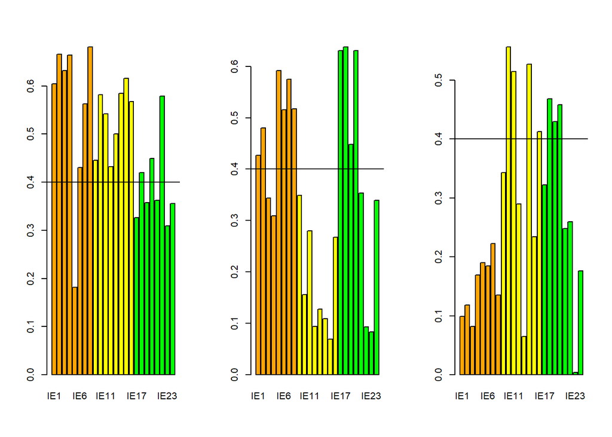

```r
satu_abs = abs(AF$loadings)
par(mfrow = c(1,3))
barplot(satu_abs[, 1], col = colores)
abline(h = 0.4, col = "black")
barplot(satu_abs[, 2], col = colores)
abline(h = 0.4, col = "black")
barplot(satu_abs[, 3], col = colores)
abline(h = 0.4, col = "black")
```

```r
par(mfrow = c(1,1))
```

No se cumple la estructura teórica de del test, por lo que es necesario aplicar alguna rotación que mejore la distribución de la matriz de saturaciones.

## 4.2 Análisis Factorial con rotación

En este caso se utilizó la rotación Varimax, aunque la función `fa` permite realizar otros tipos de rotación.

```r
AF_vari = fa(TMMS, nfactors = 3, rotate = "varimax", scores = "Bartlett")
AF_vari$Structure
```

```
##
## Loadings:
##      MR1    MR3    MR2
## IE1   0.721  0.190
## IE2   0.803  0.200
## IE3   0.675  0.242  0.101
## IE4   0.697  0.206  0.191
## IE5   0.589 -0.183 -0.195
## IE6   0.696
## IE7   0.834
## IE8   0.844  0.187
## IE9          0.621  0.219
## IE10  0.103  0.813
## IE11         0.790  0.112
## IE12  0.129  0.507
## IE13  0.215  0.393  0.266
## IE14  0.147  0.780
## IE15  0.281  0.573  0.175
## IE16         0.728  0.177
## IE17 -0.137  0.131  0.756
## IE18                0.891
## IE19                0.715
## IE20         0.107  0.893
## IE21         0.135  0.544
## IE22  0.386  0.193  0.475
## IE23  0.143  0.211  0.194
## IE24         0.180  0.488
##
##                  MR1   MR3   MR2
## SS loadings    4.724 3.965 3.762
## Proportion Var 0.197 0.165 0.157
## Cumulative Var 0.197 0.362 0.519
```

Se verifica la estructura de la matriz de saturaciones luego de aplicar la rotación.

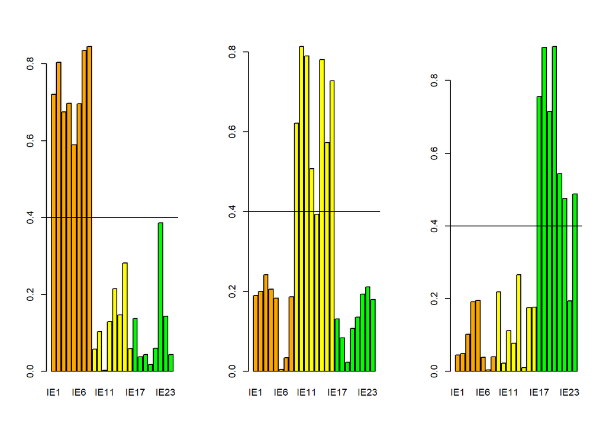

```r
satu_vari_abs = abs(AF_vari$loadings)
par(mfrow = c(1,3))
barplot(satu_vari_abs[, 1], col = colores)
abline(h = 0.4, col = "black")
barplot(satu_vari_abs[, 2], col = colores)
abline(h = 0.4, col = "black")
barplot(satu_vari_abs[, 3], col = colores)
abline(h = 0.4, col = "black")
```

```r
par(mfrow = c(1,1))
```

Esta nueva estructura de la matriz de saturaciones si se asemeja a la definida teóricamente en el Test TMMS-24.

## 4.3 Comunalidades y unicidades

La comunalidad es la proporción de varianza de las variables originales explicada por los factores. Cuando las comunalidades son altas (mayores que 0.6) todos los procedimientos tienden a dar la misma solución. Por otra parte, las unicidades son la proporción de varianza no explicada por los factores.

```r
Comunalidades = round(AF_vari$communality, 3)
Unicidades = round(AF_vari$uniquenesses, 3)
data.frame(Comunalidades, Unicidades)
```

```
##      Comunalidades Unicidades
## IE1          0.558      0.442
## IE2          0.687      0.313
## IE3          0.524      0.476
## IE4          0.565      0.435
## IE5          0.419      0.581
## IE6          0.485      0.515
## IE7          0.697      0.303
## IE8          0.749      0.251
## IE9          0.437      0.563
## IE10         0.672      0.328
## IE11         0.637      0.363
## IE12         0.280      0.720
## IE13         0.271      0.729
## IE14         0.631      0.369
## IE15         0.438      0.562
## IE16         0.564      0.436
## IE17         0.608      0.392
## IE18         0.802      0.198
## IE19         0.513      0.487
## IE20         0.809      0.191
## IE21         0.318      0.682
## IE22         0.411      0.589
## IE23         0.103      0.897
## IE24         0.272      0.728
```

La variable que se encuentra mejor explicada es IE20 (0.809), mientras que la variable IE23 es la peor explicada (0.103), ya que el modelo sólo puede explicar el 10.3% de su variabilidad original.

## 4.4 Puntuaciones factoriales

Las puntuaciones en cada dimensión retenida se calculan según el método definido. Para obtenerlas se utiliza `AF_vari$scores`

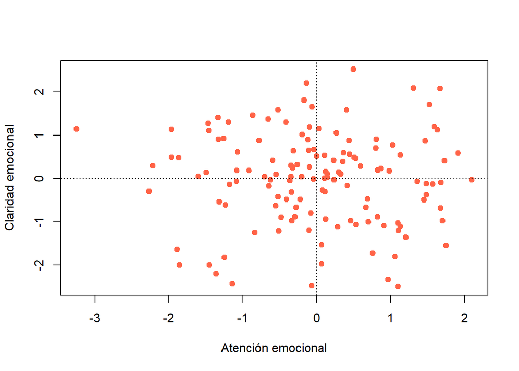

```r
puntuaciones = AF_vari$scores[,1:2]
plot(puntuaciones,
     xlab = "Atención emocional",
     ylab = "Claridad emocional",
     pch = 19,
     col = "tomato")
abline(v = 0, h = 0, lty = 3)
```